# Practical session: applying linear model

Radchuk Viktoriia

2022-12-21

# Introducing dataset

For this example we will work with the data that was gathered from multiple previously published studies.  
Q: how does temperature affects phenology (e.g. egg laying date) in birds?  
Phenology is timing of recurring biological events, such as reproduction and migration. Examples of phenological traits are: day of egg laying in birds, rut day in ungulates, day of return of migrants and the median day the butterflies are on the wings. There is growing evidence in the literature that phenological events are advancing to earlier dates across the species in the recent decades, due to warming temperatures.

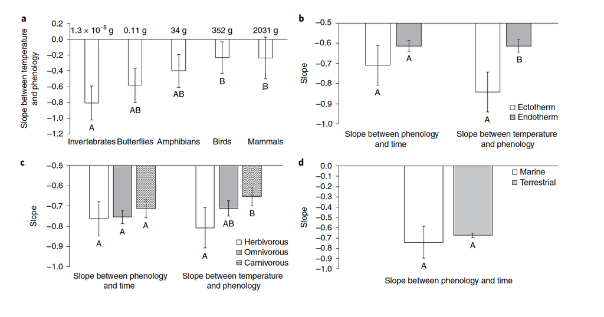

Cohen et al. Nat Clim Change 2018

We have assembled a dataset to assess how temperature affects egg laying in birds globally. In the assembled dataset we have 25 studies on 7 bird species from 12 countries.  
This is a subset of the original dataset that actually includes 155 studies on 74 species, from 25 countries.

# Getting to know the data

```r
dat <- read.csv(file = here::here('data', 'dat_phen_temp_subs.csv'))
head(dat)
```

```
##   ID Year Study_Authors                   Journal Year_pub
## 1  1 1953   Ahola_et_al Journal of Animal Ecology     2009
## 2  1 1954   Ahola_et_al Journal of Animal Ecology     2009
## 3  1 1955   Ahola_et_al Journal of Animal Ecology     2009
## 4  1 1956   Ahola_et_al Journal of Animal Ecology     2009
## 5  1 1957   Ahola_et_al Journal of Animal Ecology     2009
## 6  1 1959   Ahola_et_al Journal of Animal Ecology     2009
##                                                                                                                                    Title
## 1 Great tits lay increasingly smaller clutches than selected for: a study of climate- and density-related changes in reproductive traits
## 2 Great tits lay increasingly smaller clutches than selected for: a study of climate- and density-related changes in reproductive traits
## 3 Great tits lay increasingly smaller clutches than selected for: a study of climate- and density-related changes in reproductive traits
## 4 Great tits lay increasingly smaller clutches than selected for: a study of climate- and density-related changes in reproductive traits
## 5 Great tits lay increasingly smaller clutches than selected for: a study of climate- and density-related changes in reproductive traits
## 6 Great tits lay increasingly smaller clutches than selected for: a study of climate- and density-related changes in reproductive traits
##       Species Taxon Location Longitude Latitude Country      Trait
```

[output cut: 20 more lines]

```r
str(dat)
```

```
## 'data.frame':    750 obs. of  20 variables:
##  $ ID             : int  1 1 1 1 1 1 1 1 1 1 ...
##  $ Year           : int  1953 1954 1955 1956 1957 1959 1960 1961 1962 1963 ...
##  $ Study_Authors  : chr  "Ahola_et_al" "Ahola_et_al" "Ahola_et_al" "Ahola_et_al" ...
##  $ Journal        : chr  "Journal of Animal Ecology" "Journal of Animal Ecology" "Journal of Animal Ecology" "Journal of Animal Ecology" ...
##  $ Year_pub       : int  2009 2009 2009 2009 2009 2009 2009 2009 2009 2009 ...
##  $ Title          : chr  "Great tits lay increasingly smaller clutches than selected for: a study of climate- and density-related changes"| __truncated__ "Great tits lay increasingly smaller clutches than selected for: a study of climate- and density-related changes"| __truncated__ "Great tits la…
##  $ Species        : chr  "Parus major" "Parus major" "Parus major" "Parus major" ...
##  $ Taxon          : chr  "Bird" "Bird" "Bird" "Bird" ...
##  $ Location       : chr  "Askainen" "Askainen" "Askainen" "Askainen" ...
##  $ Longitude      : num  21.8 21.8 21.8 21.8 21.8 ...
##  $ Latitude       : num  60.6 60.6 60.6 60.6 60.6 ...
##  $ Country        : chr  "Finland" "Finland" "Finland" "Finland" ...
##  $ Trait          : chr  "LayingDate" "LayingDate" "LayingDate" "LayingDate" ...
##  $ Trait_Categ_det: chr  "Laying_Date" "Laying_Date" "Laying_Date" "Laying_Date" ...
##  $ Trait_Categ    : chr  "Phenological" "Phenological" "Phenological" "Phenological" ...
##  $ Trait_mean     : num  -1.444 -0.296 1.411 0.587 1.21 ...
##  $ Trait_SE       : num  0.166 0.0842 0.2379 0.2411 0.2762 ...
##  $ Clim           : num  3.426 1.296 -1.191 -0.631 0.757 ...
##  $ det_Clim       : num  1.585 -0.222 -2.323 -1.903 -0.8 ...
##  $ det_Clim2      : num  2.5111 0.0491 5.3941 3.6229 0.6402 ...
```

# Data preparation

We have to convert character variables to factors  
Also, the study ID should be a factor, even if its values are numeric here (pay attention: they are not consecutive, it is a subset of a larger dataset)

```r
dat_fac <- dat %>%
  mutate_if(is.character, as.factor) %>%
  mutate(ID = as.factor(ID))
str(dat_fac)
```

```
## 'data.frame':    750 obs. of  20 variables:
##  $ ID             : Factor w/ 25 levels "1","21","22",..: 1 1 1 1 1 1 1 1 1 1 ...
##  $ Year           : int  1953 1954 1955 1956 1957 1959 1960 1961 1962 1963 ...
##  $ Study_Authors  : Factor w/ 13 levels "Ahola_et_al",..: 1 1 1 1 1 1 1 1 1 1 ...
##  $ Journal        : Factor w/ 7 levels "Behavioural Ecology & Sociobiology",..: 4 4 4 4 4 4 4 4 4 4 ...
##  $ Year_pub       : int  2009 2009 2009 2009 2009 2009 2009 2009 2009 2009 ...
##  $ Title          : Factor w/ 8 levels "Bergmann?s rule and climate change revisited: Disentangling environmental and genetic responses in a wild bird population",..: 3 3 3 3 3 3 3 3 3 3 ...
##  $ Species        : Factor w/ 7 levels "Cyanistes caeruleus",..: 4 4 4 4 4 4 4 4 4 4 ...
##  $ Taxon          : Factor w/ 1 level "Bird": 1 1 1 1 1 1 1 1 1 1 ...
##  $ Location       : Factor w/ 17 levels "Askainen","Boshoek, Antwerp",..: 1 1 1 1 1 1 1 1 1 1 ...
##  $ Longitude      : num  21.8 21.8 21.8 21.8 21.8 ...
##  $ Latitude       : num  60.6 60.6 60.6 60.6 60.6 ...
##  $ Country        : Factor w/ 12 levels "Belgium","Canada",..: 4 4 4 4 4 4 4 4 4 4 ...
##  $ Trait          : Factor w/ 4 levels "ArrivalDate",..: 3 3 3 3 3 3 3 3 3 3 ...
##  $ Trait_Categ_det: Factor w/ 2 levels "Arrival_Date",..: 2 2 2 2 2 2 2 2 2 2 ...
##  $ Trait_Categ    : Factor w/ 1 level "Phenological": 1 1 1 1 1 1 1 1 1 1 ...
##  $ Trait_mean     : num  -1.444 -0.296 1.411 0.587 1.21 ...
##  $ Trait_SE       : num  0.166 0.0842 0.2379 0.2411 0.2762 ...
##  $ Clim           : num  3.426 1.296 -1.191 -0.631 0.757 ...
##  $ det_Clim       : num  1.585 -0.222 -2.323 -1.903 -0.8 ...
##  $ det_Clim2      : num  2.5111 0.0491 5.3941 3.6229 0.6402 ...
```

```r
## pay attention to the number of studies, number of species and number of countries, from which they are coming
levels(dat_fac$Species)
```

```
## [1] "Cyanistes caeruleus"              "Hirundo rustica"
## [3] "Larus novaehollandiae scopulinus" "Parus major"
## [5] "Sterna hirundo"                   "Sterna paradisaea"
## [7] "Uria aalge"
```

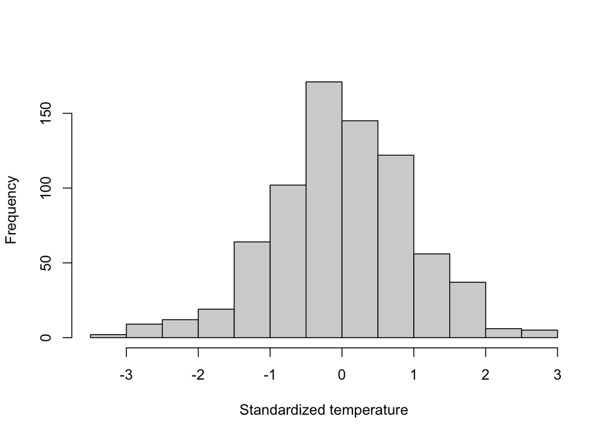

```r
hist(dat_fac$det_Clim, xlab = 'Standardized temperature', main = NULL)
```

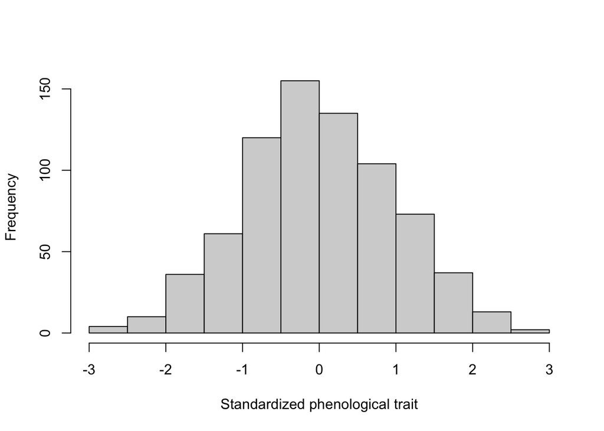

```r
hist(dat_fac$Trait_mean, xlab = 'Standardized phenological trait', main = NULL)
```

# Relation between temperature and phenology

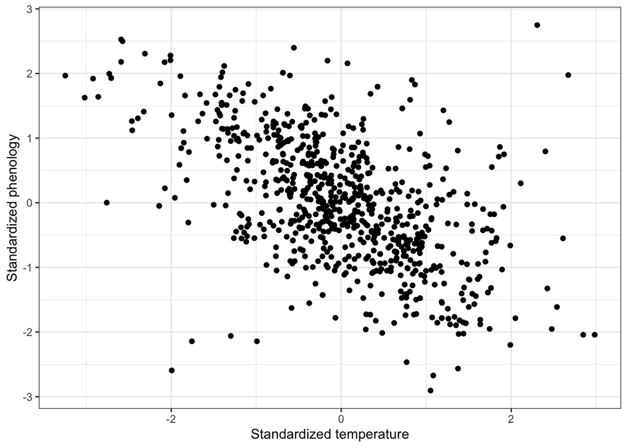

```r
ggplot(dat_fac, aes(x = det_Clim, y = Trait_mean)) +
  geom_point() + theme_bw() +
  xlab('Standardized temperature') +
  ylab('Standardized phenology')
```

# Let us have a loook at this relation per species

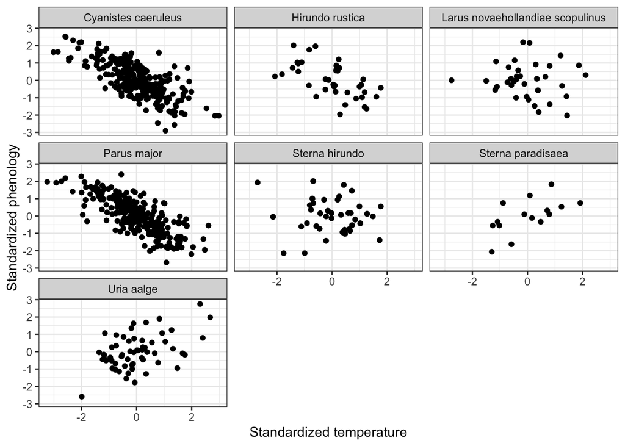

```r
ggplot(dat_fac, aes(x = det_Clim, y = Trait_mean)) +
  geom_point() + theme_bw() +
  facet_wrap(vars(Species)) +
  xlab('Standardized temperature') +
  ylab('Standardized phenology')
```

We have more data points for some species than for the others because some species were observed in several locations, so there are multiple studies from different locations for the same species.  
Let us have a look at the relation per study ID.

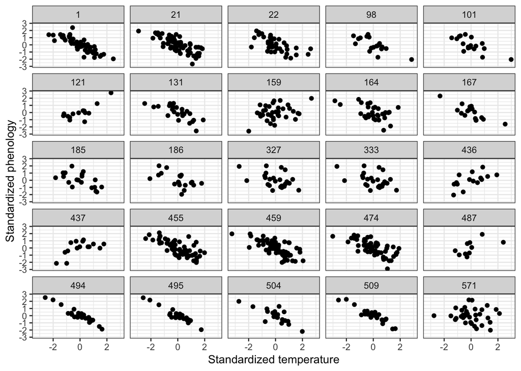

```r
ggplot(dat_fac, aes(x = det_Clim, y = Trait_mean)) +
  geom_point() + theme_bw() +
  facet_wrap(vars(ID)) +
  xlab('Standardized temperature') +
  ylab('Standardized phenology')
```

```r
table(dat_fac$Species, dat_fac$ID)
```

```
##
##                                     1 21 22 98 101 121 131 159 164 167 185 186
##   Cyanistes caeruleus               0  0  0 18  18   0  25   0  31  17   0   0
##   Hirundo rustica                   0  0  0  0   0   0   0   0   0   0  19  19
##   Larus novaehollandiae scopulinus  0  0  0  0   0   0   0   0   0   0   0   0
##   Parus major                      54 63 38  0   0   0   0   0   0   0   0   0
##   Sterna hirundo                    0  0  0  0   0   0   0   0   0   0   0   0
##   Sterna paradisaea                 0  0  0  0   0   0   0   0   0   0   0   0
##   Uria aalge                        0  0  0  0   0  14   0  35   0   0   0   0
##
##                                    327 333 436 437 455 459 474 487 494 495 504
##   Cyanistes caeruleus                0   0   0   0  60   0  58   0  25  23   0
##   Hirundo rustica                    0   0   0   0   0   0   0   0   0   0   0
##   Larus novaehollandiae scopulinus   0   0   0   0   0   0   0   0   0   0   0
##   Parus major                        0   0   0   0   0  63   0   0   0   0  20
##   Sterna hirundo                    25  25   0  15   0   0   0   0   0   0   0
##   Sterna paradisaea                  0   0  15   0   0   0   0   0   0   0   0
##   Uria aalge                         0   0   0   0   0   0   0  10   0   0   0
##
##                                    509 571
##   Cyanistes caeruleus                0   0
##   Hirundo rustica                    0   0
##   Larus novaehollandiae scopulinus   0  35
##   Parus major                       25   0
##   Sterna hirundo                     0   0
##   Sterna paradisaea                  0   0
##   Uria aalge                         0   0
```

```r
table(dat_fac$Species, dat_fac$Location)
```

```
##
##                                    Askainen Boshoek, Antwerp
##   Cyanistes caeruleus                     0               48
##   Hirundo rustica                         0                0
##   Larus novaehollandiae scopulinus        0                0
##   Parus major                            54               25
##   Sterna hirundo                          0                0
##   Sterna paradisaea                       0                0
##   Uria aalge                              0                0
##
##                                    Boswachter, Antwerp Country island
##   Cyanistes caeruleus                                0              0
##   Hirundo rustica                                    0              0
##   Larus novaehollandiae scopulinus                   0              0
##   Parus major                                       20              0
##   Sterna hirundo                                     0             15
##   Sterna paradisaea                                  0             15
##   Uria aalge                                         0              0
##
##                                    De Hoge Veluwe Deciduous-Rouviere
##   Cyanistes caeruleus                          58                 25
##   Hirundo rustica                               0                  0
##   Larus novaehollandiae scopulinus              0                  0
##   Parus major                                 101                  0
##   Sterna hirundo                                0                  0
##   Sterna paradisaea                             0                  0
##   Uria aalge                                    0                  0
##
##                                    Evergeen-Muro, Corsica
##   Cyanistes caeruleus                                  36
##   Hirundo rustica                                       0
##   Larus novaehollandiae scopulinus                      0
##   Parus major                                           0
##   Sterna hirundo                                        0
##   Sterna paradisaea                                     0
##   Uria aalge                                            0
##
##                                    Evergreen-Pirio, Corsica Isle of May
##   Cyanistes caeruleus                                    31           0
##   Hirundo rustica                                         0           0
```

[output cut: 17 more lines]

```
##   Hirundo rustica                                          0            0
##   Larus novaehollandiae scopulinus                         0            0
##   Parus major                                              0            0
##   Sterna hirundo                                           0            0
##   Sterna paradisaea                                        0            0
##   Uria aalge                                              14           10
##
##                                    Vlieland Wilhelmshaven
##   Cyanistes caeruleus                     0             0
##   Hirundo rustica                         0             0
##   Larus novaehollandiae scopulinus        0             0
##   Parus major                            63             0
##   Sterna hirundo                          0            50
##   Sterna paradisaea                       0             0
##   Uria aalge                              0             0
```

# Fit a model with all data together

```r
modAll <- lm(Trait_mean ~ det_Clim, data = dat_fac)
summary(modAll)
```

```
##
## Call:
## lm(formula = Trait_mean ~ det_Clim, data = dat_fac)
##
## Residuals:
##     Min      1Q  Median      3Q     Max
## -3.6803 -0.5272 -0.0267  0.5302  4.0056
##
## Coefficients:
##               Estimate Std. Error t value Pr(>|t|)
## (Intercept)  3.368e-16  3.015e-02    0.00        1
## det_Clim    -5.448e-01  3.066e-02  -17.77   <2e-16 ***
## ---
## Signif. codes:  0 '***' 0.001 '**' 0.01 '*' 0.05 '.' 0.1 ' ' 1
##
## Residual standard error: 0.8256 on 748 degrees of freedom
## Multiple R-squared:  0.2968, Adjusted R-squared:  0.2959
## F-statistic: 315.7 on 1 and 748 DF,  p-value: < 2.2e-16
```

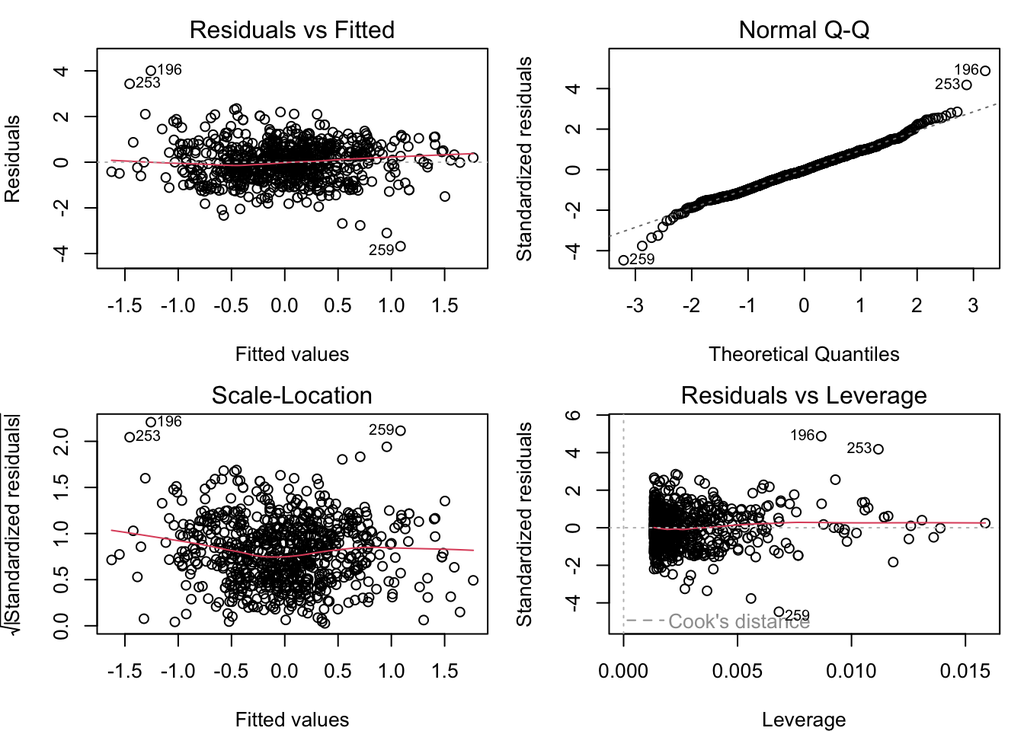

```r
par(mfrow = c(2,2), mar = c(4, 4, 2, 1))
plot(modAll)
```

## Interpreting the diagnostics plots

It is also useful to see how residuals are distributed against each of your predictors.

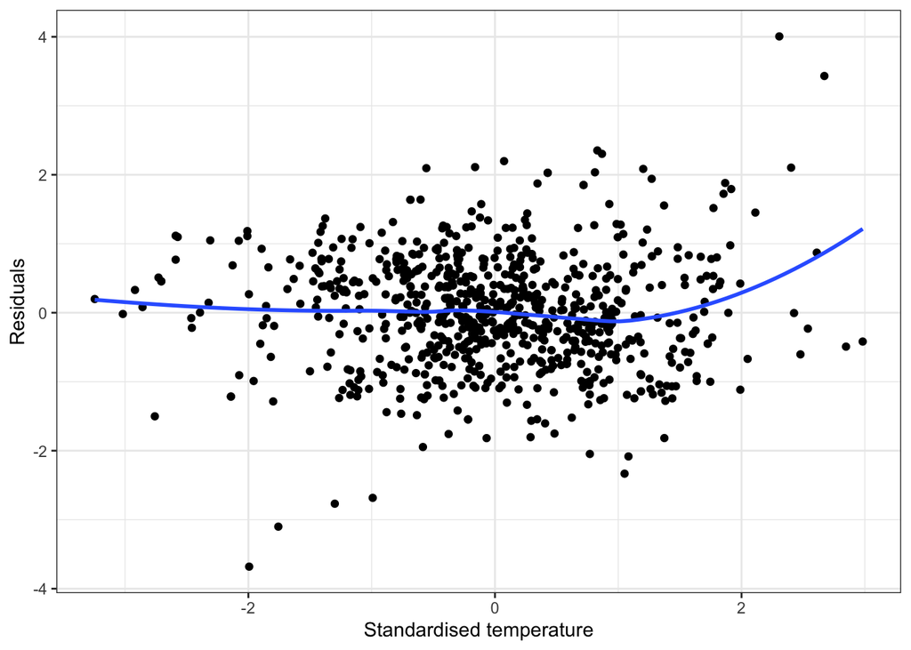

```r
dat_fac$Res_lm <- resid(modAll)
ggplot(dat_fac, aes(x = det_Clim, y = Res_lm)) +
  geom_point() +
  geom_smooth(method = 'loess', se = FALSE)  +
  theme_bw() + xlab('Standardised temperature') +
  ylab('Residuals')
```

If we see a strong non-linear pattern in this diagnostics plot, the linearity assumption was not met.

**Attention: model diagnostics plot is not an absolute test of the model assumptions. The model diagnostics may look all fine, even if some of the model assumptions are violated!!!!**

In our case, data points per each species are not independent, i.e. there is a structure in the data imposed by species

## Interpreting the model output

$y = \alpha + \beta\times x + \epsilon$, $\epsilon \sim N(0, \sigma^2)$  
$\alpha$ is intercept, i.e. the value of the response variable when the predictor = 0,

$\beta$ is slope, i.e. by how much the response variable is increasing per each unit of the predictor

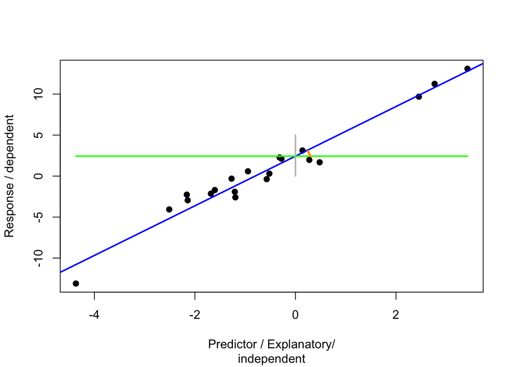

```r
summary(modAll)
```

```
##
## Call:
## lm(formula = Trait_mean ~ det_Clim, data = dat_fac)
##
## Residuals:
##     Min      1Q  Median      3Q     Max
## -3.6803 -0.5272 -0.0267  0.5302  4.0056
##
## Coefficients:
##               Estimate Std. Error t value Pr(>|t|)
## (Intercept)  3.368e-16  3.015e-02    0.00        1
## det_Clim    -5.448e-01  3.066e-02  -17.77   <2e-16 ***
## ---
## Signif. codes:  0 '***' 0.001 '**' 0.01 '*' 0.05 '.' 0.1 ' ' 1
##
## Residual standard error: 0.8256 on 748 degrees of freedom
## Multiple R-squared:  0.2968, Adjusted R-squared:  0.2959
## F-statistic: 315.7 on 1 and 748 DF,  p-value: < 2.2e-16
```

**Intercept:** the value of phenology (response variable) when the value of temperature (i.e. predictor variable) is 0. In this case the temperature of 0 corresponds to mean temperature as the data are standardized.  
**Slope:** By how much the phenology changes if we change the temperature by one unit (in this case 1 SE of temperature, since the data are standardized). So, with an increase in temperature by 1 SE the phenology (e.g. egg laying date) declines by 0.54 of temperature SE.  
**Residual Standard Error:** a measure of the quality of a model fit. The Residual Standard Error is the average amount by which the response will deviate from the true regression line. Given that the average phenology of all species is ~ 0, the Residual Standard Error of ~0.8 means that the percentage error is 80%. How good is our model??? Important: degrees of freedom are calculated as the number of data points minus the number of estimated parameters. How many parameters do we estimate in this model?  
**R-squared:** a measure of how good the model is fitting the data. It shows the proportion of the explained variance in our data, the higher the proportion of the explained variance, the closer is $R^2$ to 1, and as the variance explained in the response variable declines, $R^2$ approaches 0. Our model is explaining the data rather poorly.  
**F statistic**: tests whether there is a relationship between the predictor(s) and the response variable. The larger F, the better. But how large it should be for the model to fit the data well depends on the number of data points. Whether model fits the data well is then shown by the p value associated with this F statistic.

# Consider species explicitly

## Test for interaction between the species and temperature

What is a statistical interaction? What does it mean that species and temperature interact in their effect on phenology?

### Fit the model with interaction

```r
mod_SpInteract <- lm(Trait_mean ~ det_Clim + Species + det_Clim:Species, data = dat_fac)
summary(mod_SpInteract)
```

```
##
## Call:
## lm(formula = Trait_mean ~ det_Clim + Species + det_Clim:Species,
##     data = dat_fac)
##
## Residuals:
##      Min       1Q   Median       3Q      Max
## -2.51585 -0.46580  0.00523  0.48144  2.19054
##
## Coefficients:
##                                                    Estimate Std. Error t value
## (Intercept)                                       1.008e-16  4.433e-02   0.000
## det_Clim                                         -7.359e-01  4.508e-02 -16.326
## SpeciesHirundo rustica                           -9.406e-16  1.272e-01   0.000
## SpeciesLarus novaehollandiae scopulinus           4.417e-16  1.319e-01   0.000
## SpeciesParus major                                5.873e-16  6.341e-02   0.000
## SpeciesSterna hirundo                             3.561e-16  1.014e-01   0.000
## SpeciesSterna paradisaea                          7.322e-16  1.949e-01   0.000
## SpeciesUria aalge                                 3.842e-16  1.055e-01   0.000
## det_Clim:SpeciesHirundo rustica                   1.421e-01  1.306e-01   1.089
## det_Clim:SpeciesLarus novaehollandiae scopulinus  6.441e-01  1.339e-01   4.810
## det_Clim:SpeciesParus major                      -2.790e-02  6.430e-02  -0.434
## det_Clim:SpeciesSterna hirundo                    5.239e-01  1.037e-01   5.053
## det_Clim:SpeciesSterna paradisaea                 1.341e+00  2.016e-01   6.655
## det_Clim:SpeciesUria aalge                        1.204e+00  1.081e-01  11.143
##                                                  Pr(>|t|)
## (Intercept)                                         1.000
## det_Clim                                          < 2e-16 ***
## SpeciesHirundo rustica                              1.000
## SpeciesLarus novaehollandiae scopulinus             1.000
## SpeciesParus major                                  1.000
## SpeciesSterna hirundo                               1.000
## SpeciesSterna paradisaea                            1.000
## SpeciesUria aalge                                   1.000
## det_Clim:SpeciesHirundo rustica                     0.277
## det_Clim:SpeciesLarus novaehollandiae scopulinus 1.83e-06 ***
## det_Clim:SpeciesParus major                         0.665
## det_Clim:SpeciesSterna hirundo                   5.48e-07 ***
## det_Clim:SpeciesSterna paradisaea                5.55e-11 ***
## det_Clim:SpeciesUria aalge                        < 2e-16 ***
## ---
## Signif. codes:  0 '***' 0.001 '**' 0.01 '*' 0.05 '.' 0.1 ' ' 1
##
## Residual standard error: 0.7352 on 736 degrees of freedom
## Multiple R-squared:  0.4513, Adjusted R-squared:  0.4416
## F-statistic: 46.57 on 13 and 736 DF,  p-value: < 2.2e-16
```

Why do we have 736 degrees of freedom?  
Let us interpret the output. Is interaction significant?

Check model diagnostics

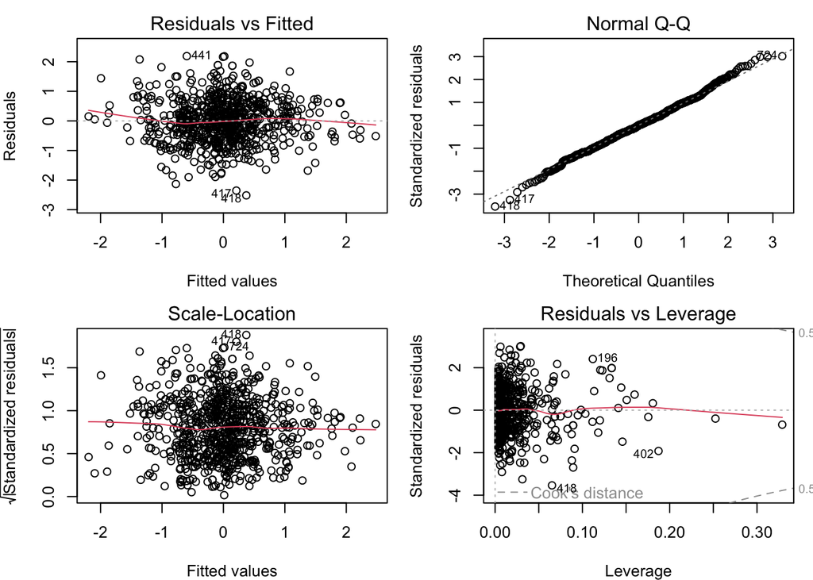

```r
par(mfrow = c(2,2), mar = c(4, 4, 2, 1))
plot(mod_SpInteract)
```

### Fit the model with the additive impact of temperature and species

```r
mod_SpAdd <- lm(Trait_mean ~ det_Clim + Species, data = dat_fac)
summary(mod_SpAdd)
```

```
##
## Call:
## lm(formula = Trait_mean ~ det_Clim + Species, data = dat_fac)
##
## Residuals:
##     Min      1Q  Median      3Q     Max
## -3.6803 -0.5272 -0.0267  0.5302  4.0056
##
## Coefficients:
##                                           Estimate Std. Error t value Pr(>|t|)
## (Intercept)                              1.438e-16  4.998e-02     0.0        1
## det_Clim                                -5.448e-01  3.078e-02   -17.7   <2e-16
## SpeciesHirundo rustica                  -9.959e-16  1.435e-01     0.0        1
## SpeciesLarus novaehollandiae scopulinus  2.198e-16  1.488e-01     0.0        1
## SpeciesParus major                       4.885e-16  7.149e-02     0.0        1
## SpeciesSterna hirundo                    4.028e-16  1.143e-01     0.0        1
## SpeciesSterna paradisaea                -7.834e-16  2.198e-01     0.0        1
## SpeciesUria aalge                        5.416e-16  1.189e-01     0.0        1
##
## (Intercept)
## det_Clim                                ***
## SpeciesHirundo rustica
## SpeciesLarus novaehollandiae scopulinus
## SpeciesParus major
## SpeciesSterna hirundo
## SpeciesSterna paradisaea
## SpeciesUria aalge
## ---
## Signif. codes:  0 '***' 0.001 '**' 0.01 '*' 0.05 '.' 0.1 ' ' 1
##
## Residual standard error: 0.8289 on 742 degrees of freedom
## Multiple R-squared:  0.2968, Adjusted R-squared:  0.2902
## F-statistic: 44.74 on 7 and 742 DF,  p-value: < 2.2e-16
```

## Likelihood-Ratio Test to assess significance

```r
anova(mod_SpAdd, mod_SpInteract, test = 'Chisq')
```

```
## Analysis of Variance Table
##
## Model 1: Trait_mean ~ det_Clim + Species
## Model 2: Trait_mean ~ det_Clim + Species + det_Clim:Species
##   Res.Df    RSS Df Sum of Sq  Pr(>Chi)
## 1    742 509.81
## 2    736 397.80  6    112.01 < 2.2e-16 ***
## ---
## Signif. codes:  0 '***' 0.001 '**' 0.01 '*' 0.05 '.' 0.1 ' ' 1
```

One cannot rely on the p values output from `lm()` call if one has as predictors factors with >2 levels. To assess whether that factor is significant (or, as in this case, whether an interaction of such a factor with another variable is significant), we usually rely on LRT.  
LRT assesses the goodness of fit of two competing models using the ratio of their likelihoods. It is based on Chi2 statistics.  
**We find a significant interaction between species and temperature. Besides, this model fits the data much better than the one without species (see adjusted R-Squared)**  
Still, even though the fit is much better than that of the model with temperature only as a predictor, this model is still doing not a good job at explaining the variance in the data (Adjusted $R^2$ is 0.442)

# Plot predictions of this model

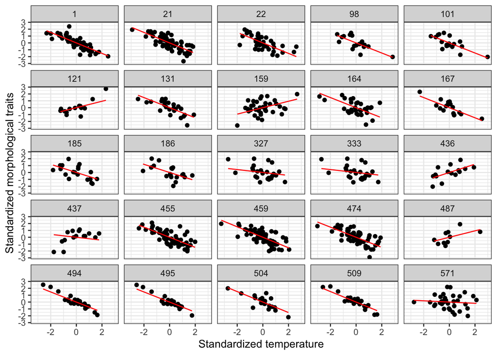

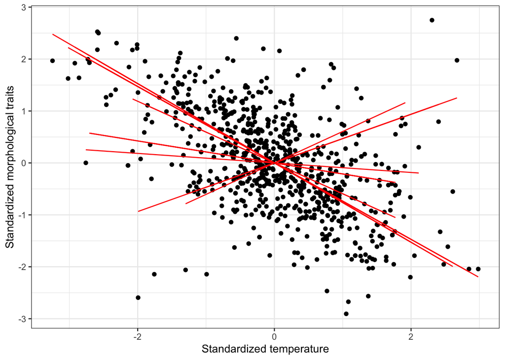

# References

- Cohen JM, Lajeunesse MJ & Rohr JR (2018) A global synthesis of animal phenological responses to climate change. *Nature Climate Change* doi:10.1038/s41558-018-0067-3.
- Thackeray SJ et al. (2016) Phenological sensitivity to climate across taxa and trophic levels. *Nature* 535, 241–245.